# Case_study

## Case study: Mental Health in Tech Survey

source: Kaggle [https://www.kaggle.com/datasets/osmi/mental-health-in-tech-survey]

## Motivation

In this project, I aim to undertake an analysis that, besides enriching my knowledge in the field of machine learning systems, could potentially contribute to improving the quality of life for myself and others. I have chosen a dataset that contains information collected from individuals working in the technology industry regarding their mental well-being. I believe that the results of the analysis can be useful and interesting, and due to the presence of mental health issues and the technology industry, they align well with my interests and the scientific-technical environment in which I operate.

## Conditional Attributes

(Below, I provide all the attributes available in the dataset, although during the project, I plan to examine the significance of each of them and, depending on the result of the analysis, choose those that carry the most information):

- Timestamp
- Age
- Gender
- Country
- state: If you live in the United States, which state or territory do you live in?
- self_employed: Are you self-employed?
- family_history: Do you have a family history of mental illness?
- work_interfere: If you have a mental health condition, do you feel that it interferes with your work?
- no_employees: How many employees does your company or organization have?
- remote_work: Do you work remotely (outside of an office) at least 50% of the time?
- tech_company: Is your employer primarily a tech company/organization?
- benefits: Does your employer provide mental health benefits?
- care_options: Do you know the options for mental health care your employer provides?
- wellness_program: Has your employer ever discussed mental health as part of an employee wellness program?
- seek_help: Does your employer provide resources to learn more about mental health issues and how to seek help?
- anonymity: Is your anonymity protected if you choose to take advantage of mental health or substance abuse treatment resources?
- leave: How easy is it for you to take medical leave for a mental health condition?
- mentalhealthconsequence: Do you think that discussing a mental health issue with your employer would have negative consequences?
- physhealthconsequence: Do you think that discussing a physical health issue with your employer would have negative consequences?
- coworkers: Would you be willing to discuss a mental health issue with your coworkers?
- supervisor: Would you be willing to discuss a mental health issue with your direct supervisor(s)?
- mentalhealthinterview: Would you bring up a mental health issue with a potential employer in an interview?
- physhealthinterview: Would you bring up a physical health issue with a potential employer in an interview?
- mentalvsphysical: Do you feel that your employer takes mental health as seriously as physical health?
- obs_consequence: Have you heard of or observed negative consequences for coworkers with mental health conditions in your workplace?
- comments: Any additional notes or comments

## Decision Attribute

**"treatment - Have you sought treatment for a mental health condition?"** with values True, False. It indicates whether the respondent has sought help to improve their mental condition.

## Identified Challenges:

A potential challenge could be the **bias in the analyzed data** - the survey was reviewed by an organization dealing with mental health, which may suggest that it more often reached people who observed health problems in themselves and sought help, for example, on the website of the mentioned organization, than healthy individuals.

Additionally, in the preliminary analysis, I noticed **disproportion between the number of women and men**, although I think this is due to an uneven gender distribution in the technical sector. **Some data will require correction** (for example, in the "gender" field, values other than "Male" and "Female" sometimes appear, e.g., "M", "Fe"), or **completion of missing values**. It may also be necessary to **convert text responses** (e.g., frequency terms like "Often" or "Sometimes") into numbers.

However, I believe that to a greater or lesser extent, such challenges affect all datasets, especially those that derive information from surveys. Despite identified flaws, I would like to undertake the analysis of this dataset.

## Data loading

```python
import pandas as pd
import matplotlib.pyplot as plt
import seaborn as sns

df = pd.read_csv('survey.csv')
df
```

|  | Timestamp | Age | Gender | Country | state | self_employed | family_history | treatment | work_interfere | no_employees | ... | leave | mental_health_consequence | phys_health_consequence | coworkers | supervisor | mental_health_interview | phys_health_interview | mental_vs_physical | obs_consequence | comments |
| --- | --- | --- | --- | --- | --- | --- | --- | --- | --- | --- | --- | --- | --- | --- | --- | --- | --- | --- | --- | --- | --- |
| 0 | 2014-08-27 11:29:31 | 37 | Female | United States | IL | NaN | No | Yes | Often | 6-25 | ... | Somewhat easy | No | No | Some of them | Yes | No | Maybe | Yes | No | NaN |
| 1 | 2014-08-27 11:29:37 | 44 | M | United States | IN | NaN | No | No | Rarely | More than 1000 | ... | Don't know | Maybe | No | No | No | No | No | Don't know | No | NaN |
| 2 | 2014-08-27 11:29:44 | 32 | Male | Canada | NaN | NaN | No | No | Rarely | 6-25 | ... | Somewhat difficult | No | No | Yes | Yes | Yes | Yes | No | No | NaN |
| 3 | 2014-08-27 11:29:46 | 31 | Male | United Kingdom | NaN | NaN | Yes | Yes | Often | 26-100 | ... | Somewhat difficult | Yes | Yes | Some of them | No | Maybe | Maybe | No | Yes | NaN |
| 4 | 2014-08-27 11:30:22 | 31 | Male | United States | TX | NaN | No | No | Never | 100-500 | ... | Don't know | No | No | Some of them | Yes | Yes | Yes | Don't know | No | NaN |
| ... | ... | ... | ... | ... | ... | ... | ... | ... | ... | ... | ... | ... | ... | ... | ... | ... | ... | ... | ... | ... | ... |
| 1254 | 2015-09-12 11:17:21 | 26 | male | United Kingdom | NaN | No | No | Yes | NaN | 26-100 | ... | Somewhat easy | No | No | Some of them | Some of them | No | No | Don't know | No | NaN |
| 1255 | 2015-09-26 01:07:35 | 32 | Male | United States | IL | No | Yes | Yes | Often | 26-100 | ... | Somewhat difficult | No | No | Some of them | Yes | No | No | Yes | No | NaN |
| 1256 | 2015-11-07 12:36:58 | 34 | male | United States | CA | No | Yes | Yes | Sometimes | More than 1000 | ... | Somewhat difficult | Yes | Yes | No | No | No | No | No | No | NaN |
| 1257 | 2015-11-30 21:25:06 | 46 | f | United States | NC | No | No | No | NaN | 100-500 | ... | Don't know | Yes | No | No | No | No | No | No | No | NaN |
| 1258 | 2016-02-01 23:04:31 | 25 | Male | United States | IL | No | Yes | Yes | Sometimes | 26-100 | ... | Don't know | Maybe | No | Some of them | No | No | No | Don't know | No | NaN |

1259 rows × 27 columns

## Preliminary Data Processing:

Below, I present the count and percentage share of empty values for each attribute:

```python
df.isnull().apply(lambda x: f"{x.sum()} -> { round( x.mean()*100, 2) }%")
```

```
Timestamp                         0 -> 0.0%
Age                               0 -> 0.0%
Gender                            0 -> 0.0%
Country                           0 -> 0.0%
state                         515 -> 40.91%
self_employed                   18 -> 1.43%
family_history                    0 -> 0.0%
treatment                         0 -> 0.0%
work_interfere                264 -> 20.97%
no_employees                      0 -> 0.0%
remote_work                       0 -> 0.0%
tech_company                      0 -> 0.0%
benefits                          0 -> 0.0%
care_options                      0 -> 0.0%
wellness_program                  0 -> 0.0%
seek_help                         0 -> 0.0%
anonymity                         0 -> 0.0%
leave                             0 -> 0.0%
mental_health_consequence         0 -> 0.0%
phys_health_consequence           0 -> 0.0%
coworkers                         0 -> 0.0%
supervisor                        0 -> 0.0%
mental_health_interview           0 -> 0.0%
phys_health_interview             0 -> 0.0%
mental_vs_physical                0 -> 0.0%
obs_consequence                   0 -> 0.0%
comments                     1095 -> 86.97%
dtype: object
```

```python
df = df.drop(['state','comments','Timestamp','work_interfere'], axis=1)
df.isnull().apply(lambda x: f"{x.sum()} -> { round( x.mean()*100, 2) }%")
```

```
Age                            0 -> 0.0%
Gender                         0 -> 0.0%
Country                        0 -> 0.0%
self_employed                18 -> 1.43%
family_history                 0 -> 0.0%
treatment                      0 -> 0.0%
no_employees                   0 -> 0.0%
remote_work                    0 -> 0.0%
tech_company                   0 -> 0.0%
benefits                       0 -> 0.0%
care_options                   0 -> 0.0%
wellness_program               0 -> 0.0%
seek_help                      0 -> 0.0%
anonymity                      0 -> 0.0%
leave                          0 -> 0.0%
mental_health_consequence      0 -> 0.0%
phys_health_consequence        0 -> 0.0%
coworkers                      0 -> 0.0%
supervisor                     0 -> 0.0%
mental_health_interview        0 -> 0.0%
phys_health_interview          0 -> 0.0%
mental_vs_physical             0 -> 0.0%
obs_consequence                0 -> 0.0%
dtype: object
```

## Standardization of Values for the "gender" Attribute.

To achieve this, I used manually written rules and the "autocorrect" module, which corrects typos in words. In the input dataset for the gender attribute, there were as many as 49 different values (!), which are presented in the cell below.

```python
print(len(set(df['Gender'])))
print(set(df['Gender']))

from autocorrect import Speller
spell = Speller(lang='en')

def map_gender(gender):

    val = spell(gender.lower())
    if 'female' in val or val in ['f','woman','email']:
        return 'female'
    elif 'male' in val or 'guy' in val or val in ['m','man','mal','mail','make','cis man']:
        return 'male'
    elif 'queer' in val or 'trans' in val or val in ['androgen','agender','fluid','non-binary','gender','envy','p','all','neuter','nah','a little about you']:
        return 'queer'

    print(val)
    raise AssertionError()

for gen in set(df['Gender']):
    if map_gender(gen)=="UNDEFINED": print(gen,spell(gen.lower()), map_gender(gen))

df['Gender'] = df['Gender'].apply(map_gender)
df
```

```
49
{'Make', 'Female ', 'Androgyne', 'Female (trans)', 'Malr', 'queer', 'Guy (-ish) ^_^', 'Woman', 'All', 'Male ', 'female', 'queer/she/they', 'f', 'male leaning androgynous', 'M', 'Agender', 'Male', 'maile', 'ostensibly male, unsure what that really means', 'msle', 'Trans-female', 'Female (cis)', 'F', …
```

|  | Age | Gender | Country | self_employed | family_history | treatment | no_employees | remote_work | tech_company | benefits | ... | anonymity | leave | mental_health_consequence | phys_health_consequence | coworkers | supervisor | mental_health_interview | phys_health_interview | mental_vs_physical | obs_consequence |
| --- | --- | --- | --- | --- | --- | --- | --- | --- | --- | --- | --- | --- | --- | --- | --- | --- | --- | --- | --- | --- | --- |
| 0 | 37 | female | United States | NaN | No | Yes | 6-25 | No | Yes | Yes | ... | Yes | Somewhat easy | No | No | Some of them | Yes | No | Maybe | Yes | No |
| 1 | 44 | male | United States | NaN | No | No | More than 1000 | No | No | Don't know | ... | Don't know | Don't know | Maybe | No | No | No | No | No | Don't know | No |
| 2 | 32 | male | Canada | NaN | No | No | 6-25 | No | Yes | No | ... | Don't know | Somewhat difficult | No | No | Yes | Yes | Yes | Yes | No | No |
| 3 | 31 | male | United Kingdom | NaN | Yes | Yes | 26-100 | No | Yes | No | ... | No | Somewhat difficult | Yes | Yes | Some of them | No | Maybe | Maybe | No | Yes |
| 4 | 31 | male | United States | NaN | No | No | 100-500 | Yes | Yes | Yes | ... | Don't know | Don't know | No | No | Some of them | Yes | Yes | Yes | Don't know | No |
| ... | ... | ... | ... | ... | ... | ... | ... | ... | ... | ... | ... | ... | ... | ... | ... | ... | ... | ... | ... | ... | ... |
| 1254 | 26 | male | United Kingdom | No | No | Yes | 26-100 | No | Yes | No | ... | Don't know | Somewhat easy | No | No | Some of them | Some of them | No | No | Don't know | No |
| 1255 | 32 | male | United States | No | Yes | Yes | 26-100 | Yes | Yes | Yes | ... | Yes | Somewhat difficult | No | No | Some of them | Yes | No | No | Yes | No |
| 1256 | 34 | male | United States | No | Yes | Yes | More than 1000 | No | Yes | Yes | ... | Don't know | Somewhat difficult | Yes | Yes | No | No | No | No | No | No |
| 1257 | 46 | female | United States | No | No | No | 100-500 | Yes | Yes | No | ... | Don't know | Don't know | Yes | No | No | No | No | No | No | No |
| 1258 | 25 | male | United States | No | Yes | Yes | 26-100 | No | No | Yes | ... | Yes | Don't know | Maybe | No | Some of them | No | No | No | Don't know | No |

1259 rows × 23 columns

## Filling and Correcting Missing or Incorrect Data

```python
import random

print("Values of the age and self_employed attributes before corrections\n")

for col in ['Age','self_employed']:
    print(col, set(df[col]))

df['Age'] = df['Age'].apply(lambda x: df['Age'].median() if x < 5 or x > 100  else x)
df['self_employed'] = df['self_employed'].apply(lambda x: 'Yes' if random.random() < 0.5 else 'No')

print("\nValues after corrections\n")

for col in ['Age','self_employed']:
    print(col, set(df[col]))
```

```
Values of the age and self_employed attributes before corrections

Age {5, 8, 11, 18, 19, 20, 21, 22, 23, 24, 25, 26, 27, 28, 29, 30, 31, 32, 33, 34, 35, 36, 37, 38, 39, 40, 41, 42, 43, 44, 45, 46, 47, 48, 49, 50, 51, 53, 54, 55, 56, 57, 58, 60, 61, 62, 65, -1726, 72, 329, -29, -1, 99999999999}
self_employed {nan, 'Yes', 'No'}

Values after corrections

Age {5.0, 8.0, 11.0, 18.0, 19.0, 20.0, 21.0, 22.0, 23.0, 24.0, 25.0, 26.0, 27.0, 28.0, 29.0, 30.0, 31.0, 32.0, 33.0, 34.0, 35.0, 36.0, 37.0, 38.0, 39.0, 40.0, 41.0, 42.0, 43.0, 44.0, 45.0, 46.0, 47.0, 48.0, 49.0, 50.0, 51.0, 53.0, 54.0, 55.0, 56.0, 57.0, 58.0, 60.0, 61.0, 62.0, 65.0, 72.0}
self_employed {'No', 'Yes'}
```

### Rechecking the Number of Empty Values for Each Attribute

```python
df.isnull().sum()
```

```
Age                          0
Gender                       0
Country                      0
self_employed                0
family_history               0
treatment                    0
no_employees                 0
remote_work                  0
tech_company                 0
benefits                     0
care_options                 0
wellness_program             0
seek_help                    0
anonymity                    0
leave                        0
mental_health_consequence    0
phys_health_consequence      0
coworkers                    0
supervisor                   0
mental_health_interview      0
phys_health_interview        0
mental_vs_physical           0
obs_consequence              0
dtype: int64
```

## Distribution of Values for Selected Attributes

The distribution of values for the decision attribute "treatment" is balanced, so there is no need to use class balancing methods during later training. However, the values of the "gender" attribute are unbalanced, so one should be aware of the bias resulting from it.

```python
df['treatment'].value_counts()
```

```
Yes    637
No     622
Name: treatment, dtype: int64
```

```python
df['Gender'].value_counts()
```

```
male      995
female    250
queer      14
Name: Gender, dtype: int64
```

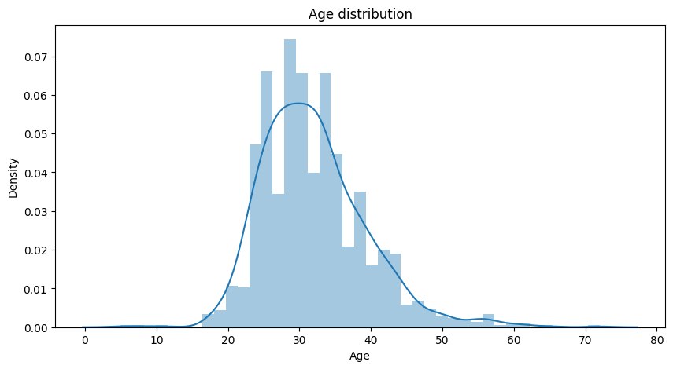

```python
plt.figure(figsize=(10,5))
sns.distplot(df["Age"])
plt.title("Age distribution")
plt.xlabel("Age")
```

## Conversion of Text Values to Numeric Using One-Hot Encoding

All attributes, excluding age and the decision attribute - treatment, which by default takes binary values (0/1), undergo the conversion process.

```python
cols = list(filter(lambda x: x not in ['Age', 'treatment'],df.columns.values.tolist()))

df = pd.get_dummies(df,
                     prefix=cols,
                     columns=cols)
df.columns
```

```
Index(['Age', 'treatment', 'Gender_female', 'Gender_male', 'Gender_queer',
       'Country_Australia', 'Country_Austria', 'Country_Bahamas, The',
       'Country_Belgium', 'Country_Bosnia and Herzegovina',
       ...
       'mental_health_interview_No', 'mental_health_interview_Yes',
       'phys_health_interview_Maybe', 'phys_health_interview_No',
       'phys_health_interview_Yes', 'mental_vs_physical_Don't know',
       'mental_vs_physical_No', 'mental_vs_physical_Yes', 'obs_consequence_No',
       'obs_consequence_Yes'],
      dtype='object', length=110)
```

## Data Scaling

For data scaling, I used the "MinMaxScaler" - a method that scales data in such a way that the minimum value for a given attribute after scaling is 0, and the maximum is 1. Scaling data is important when providing data to classifiers that operate on distance metrics during the learning process, and I will also use such classifiers for making predictions.

```python
X = df.drop(columns='treatment')
y = df['treatment'].apply(lambda x: 1 if x=='Yes' else 0)

X
```

|  | Age | Gender_female | Gender_male | Gender_queer | Country_Australia | Country_Austria | Country_Bahamas, The | Country_Belgium | Country_Bosnia and Herzegovina | Country_Brazil | ... | mental_health_interview_No | mental_health_interview_Yes | phys_health_interview_Maybe | phys_health_interview_No | phys_health_interview_Yes | mental_vs_physical_Don't know | mental_vs_physical_No | mental_vs_physical_Yes | obs_consequence_No | obs_consequence_Yes |
| --- | --- | --- | --- | --- | --- | --- | --- | --- | --- | --- | --- | --- | --- | --- | --- | --- | --- | --- | --- | --- | --- |
| 0 | 37.0 | 1 | 0 | 0 | 0 | 0 | 0 | 0 | 0 | 0 | ... | 1 | 0 | 1 | 0 | 0 | 0 | 0 | 1 | 1 | 0 |
| 1 | 44.0 | 0 | 1 | 0 | 0 | 0 | 0 | 0 | 0 | 0 | ... | 1 | 0 | 0 | 1 | 0 | 1 | 0 | 0 | 1 | 0 |
| 2 | 32.0 | 0 | 1 | 0 | 0 | 0 | 0 | 0 | 0 | 0 | ... | 0 | 1 | 0 | 0 | 1 | 0 | 1 | 0 | 1 | 0 |
| 3 | 31.0 | 0 | 1 | 0 | 0 | 0 | 0 | 0 | 0 | 0 | ... | 0 | 0 | 1 | 0 | 0 | 0 | 1 | 0 | 0 | 1 |
| 4 | 31.0 | 0 | 1 | 0 | 0 | 0 | 0 | 0 | 0 | 0 | ... | 0 | 1 | 0 | 0 | 1 | 1 | 0 | 0 | 1 | 0 |
| ... | ... | ... | ... | ... | ... | ... | ... | ... | ... | ... | ... | ... | ... | ... | ... | ... | ... | ... | ... | ... | ... |
| 1254 | 26.0 | 0 | 1 | 0 | 0 | 0 | 0 | 0 | 0 | 0 | ... | 1 | 0 | 0 | 1 | 0 | 1 | 0 | 0 | 1 | 0 |
| 1255 | 32.0 | 0 | 1 | 0 | 0 | 0 | 0 | 0 | 0 | 0 | ... | 1 | 0 | 0 | 1 | 0 | 0 | 0 | 1 | 1 | 0 |
| 1256 | 34.0 | 0 | 1 | 0 | 0 | 0 | 0 | 0 | 0 | 0 | ... | 1 | 0 | 0 | 1 | 0 | 0 | 1 | 0 | 1 | 0 |
| 1257 | 46.0 | 1 | 0 | 0 | 0 | 0 | 0 | 0 | 0 | 0 | ... | 1 | 0 | 0 | 1 | 0 | 0 | 1 | 0 | 1 | 0 |
| 1258 | 25.0 | 0 | 1 | 0 | 0 | 0 | 0 | 0 | 0 | 0 | ... | 1 | 0 | 0 | 1 | 0 | 1 | 0 | 0 | 1 | 0 |

1259 rows × 109 columns

```python
from sklearn.preprocessing import MinMaxScaler
scaler = MinMaxScaler()
X = pd.DataFrame(scaler.fit_transform(X), index=X.index, columns=X.columns)
X
```

|  | Age | Gender_female | Gender_male | Gender_queer | Country_Australia | Country_Austria | Country_Bahamas, The | Country_Belgium | Country_Bosnia and Herzegovina | Country_Brazil | ... | mental_health_interview_No | mental_health_interview_Yes | phys_health_interview_Maybe | phys_health_interview_No | phys_health_interview_Yes | mental_vs_physical_Don't know | mental_vs_physical_No | mental_vs_physical_Yes | obs_consequence_No | obs_consequence_Yes |
| --- | --- | --- | --- | --- | --- | --- | --- | --- | --- | --- | --- | --- | --- | --- | --- | --- | --- | --- | --- | --- | --- |
| 0 | 0.477612 | 1.0 | 0.0 | 0.0 | 0.0 | 0.0 | 0.0 | 0.0 | 0.0 | 0.0 | ... | 1.0 | 0.0 | 1.0 | 0.0 | 0.0 | 0.0 | 0.0 | 1.0 | 1.0 | 0.0 |
| 1 | 0.582090 | 0.0 | 1.0 | 0.0 | 0.0 | 0.0 | 0.0 | 0.0 | 0.0 | 0.0 | ... | 1.0 | 0.0 | 0.0 | 1.0 | 0.0 | 1.0 | 0.0 | 0.0 | 1.0 | 0.0 |
| 2 | 0.402985 | 0.0 | 1.0 | 0.0 | 0.0 | 0.0 | 0.0 | 0.0 | 0.0 | 0.0 | ... | 0.0 | 1.0 | 0.0 | 0.0 | 1.0 | 0.0 | 1.0 | 0.0 | 1.0 | 0.0 |
| 3 | 0.388060 | 0.0 | 1.0 | 0.0 | 0.0 | 0.0 | 0.0 | 0.0 | 0.0 | 0.0 | ... | 0.0 | 0.0 | 1.0 | 0.0 | 0.0 | 0.0 | 1.0 | 0.0 | 0.0 | 1.0 |
| 4 | 0.388060 | 0.0 | 1.0 | 0.0 | 0.0 | 0.0 | 0.0 | 0.0 | 0.0 | 0.0 | ... | 0.0 | 1.0 | 0.0 | 0.0 | 1.0 | 1.0 | 0.0 | 0.0 | 1.0 | 0.0 |
| ... | ... | ... | ... | ... | ... | ... | ... | ... | ... | ... | ... | ... | ... | ... | ... | ... | ... | ... | ... | ... | ... |
| 1254 | 0.313433 | 0.0 | 1.0 | 0.0 | 0.0 | 0.0 | 0.0 | 0.0 | 0.0 | 0.0 | ... | 1.0 | 0.0 | 0.0 | 1.0 | 0.0 | 1.0 | 0.0 | 0.0 | 1.0 | 0.0 |
| 1255 | 0.402985 | 0.0 | 1.0 | 0.0 | 0.0 | 0.0 | 0.0 | 0.0 | 0.0 | 0.0 | ... | 1.0 | 0.0 | 0.0 | 1.0 | 0.0 | 0.0 | 0.0 | 1.0 | 1.0 | 0.0 |
| 1256 | 0.432836 | 0.0 | 1.0 | 0.0 | 0.0 | 0.0 | 0.0 | 0.0 | 0.0 | 0.0 | ... | 1.0 | 0.0 | 0.0 | 1.0 | 0.0 | 0.0 | 1.0 | 0.0 | 1.0 | 0.0 |
| 1257 | 0.611940 | 1.0 | 0.0 | 0.0 | 0.0 | 0.0 | 0.0 | 0.0 | 0.0 | 0.0 | ... | 1.0 | 0.0 | 0.0 | 1.0 | 0.0 | 0.0 | 1.0 | 0.0 | 1.0 | 0.0 |
| 1258 | 0.298507 | 0.0 | 1.0 | 0.0 | 0.0 | 0.0 | 0.0 | 0.0 | 0.0 | 0.0 | ... | 1.0 | 0.0 | 0.0 | 1.0 | 0.0 | 1.0 | 0.0 | 0.0 | 1.0 | 0.0 |

1259 rows × 109 columns

### Attribute Selection

I performed attribute selection with the help of the ExtraTreesClassifier because, based on the experience gathered so far, I found it to be the most suitable for this task. Due to the large number of attributes resulting from one-hot encoding, I listed the most significant attributes along with the obtained results below the graph. In the next step, based on the obtained results, I selected the most important attributes (SelectFromModel) and appropriately modified the training and testing sets.

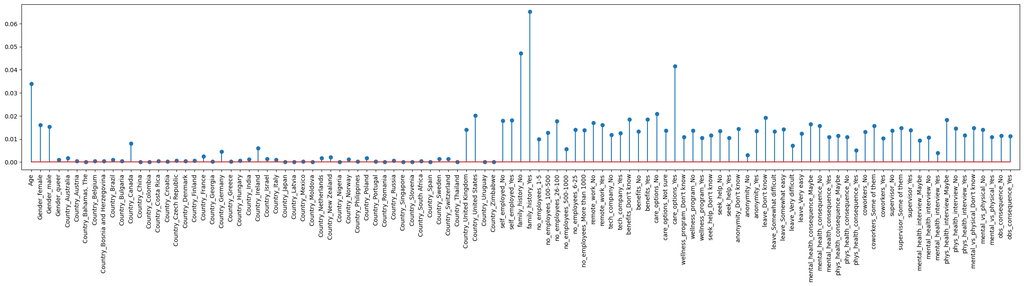

```python
from sklearn.feature_selection import SelectFromModel
from sklearn.ensemble import ExtraTreesClassifier
from sklearn.model_selection import train_test_split

X_train, X_test, y_train, y_test = train_test_split(X, y, test_size=0.33, random_state=42)

clf = ExtraTreesClassifier(n_estimators=50)
clf = clf.fit(X_train, y_train)

plt.figure(figsize=(30, 5))
plt.stem(list(X_train.columns), list(clf.feature_importances_), use_line_collection=True)
plt.xticks(rotation=90)
plt.margins(x=0.01)
plt.show()
```

```python
importances = sorted(list(zip(list(X_train.columns), list(clf.feature_importances_))),key=lambda x: x[1], reverse=True)
importances[:10]
```

```
[('family_history_Yes', 0.06513295098215635),
 ('family_history_No', 0.047141329471620794),
 ('care_options_Yes', 0.0414624804688189),
 ('Age', 0.03399170318856797),
 ('care_options_No', 0.02097607854358602),
 ('Country_United States', 0.020194702821856043),
 ("leave_Don't know", 0.01930135757720754),
 ('benefits_Yes', 0.018564707753875236),
 ("benefits_Don't know", 0.018493998499369883),
 ('phys_health_interview_Maybe', 0.018240127429870415)]
```

```python
model = SelectFromModel(clf, prefit=True)
feature_names = X_train.columns[ model.get_support() ]

print(f"Choosen attributes: {feature_names}")

X_train, X_test = X_train[feature_names], X_test[feature_names]
X = X[feature_names]
X_train
```

```
Choosen attributes: Index(['Age', 'Gender_female', 'Gender_male', 'Country_United Kingdom',
       'Country_United States', 'self_employed_No', 'self_employed_Yes',
       'family_history_No', 'family_history_Yes', 'no_employees_1-5',
       'no_employees_100-500', 'no_employees_26-100', 'no_employees_6-25',
       'no_employees_More than 1000', 'remote_work_No', 'remote_work_Yes',
       'tech_company_No', 'tech_company_Yes', 'benefits_Don't know',
       'benefits_No', 'benefits_Yes', 'care_options_No',
       'care_options_Not sure', 'care_options_Yes',
       'wellness_program_Don't know', 'wellness_program_No',
       'wellness_program_Yes', 'seek_help_Don't know', 'seek_help_No',
       'seek_help_Yes', 'anonymity_Don't know', 'anonymity_Yes',
       'leave_Don't know', 'leave_Somewhat difficult', 'leave_Somewhat easy',
       'leave_Very easy', 'mental_health_consequence_Maybe',
       'mental_health_consequence_No', 'mental_health_consequence_Yes',
       'phys_health_consequence_Maybe', 'phys_health_consequence_No',
       'coworkers_No', 'coworkers_Some of them', 'coworkers_Yes',
       'supervisor_No', 'supervisor_Some of them', 'supervisor_Yes',
       'mental_health_interview_Maybe', 'mental_health_interview_No',
       'phys_health_interview_Maybe', 'phys_health_interview_No',
       'phys_health_interview_Yes', 'mental_vs_physical_Don't know',
       'mental_vs_physical_No', 'mental_vs_physical_Yes', 'obs_consequence_No',
       'obs_consequence_Yes'],
      dtype='object')
```

|  | Age | Gender_female | Gender_male | Country_United Kingdom | Country_United States | self_employed_No | self_employed_Yes | family_history_No | family_history_Yes | no_employees_1-5 | ... | mental_health_interview_Maybe | mental_health_interview_No | phys_health_interview_Maybe | phys_health_interview_No | phys_health_interview_Yes | mental_vs_physical_Don't know | mental_vs_physical_No | mental_vs_physical_Yes | obs_consequence_No | obs_consequence_Yes |
| --- | --- | --- | --- | --- | --- | --- | --- | --- | --- | --- | --- | --- | --- | --- | --- | --- | --- | --- | --- | --- | --- |
| 423 | 0.402985 | 0.0 | 1.0 | 1.0 | 0.0 | 1.0 | 0.0 | 0.0 | 1.0 | 0.0 | ... | 0.0 | 1.0 | 0.0 | 1.0 | 0.0 | 1.0 | 0.0 | 0.0 | 1.0 | 0.0 |
| 590 | 0.432836 | 0.0 | 1.0 | 0.0 | 1.0 | 1.0 | 0.0 | 0.0 | 1.0 | 0.0 | ... | 0.0 | 1.0 | 0.0 | 0.0 | 1.0 | 1.0 | 0.0 | 0.0 | 0.0 | 1.0 |
| 1039 | 0.447761 | 0.0 | 1.0 | 0.0 | 1.0 | 1.0 | 0.0 | 1.0 | 0.0 | 0.0 | ... | 0.0 | 1.0 | 0.0 | 1.0 | 0.0 | 1.0 | 0.0 | 0.0 | 1.0 | 0.0 |
| 1027 | 0.208955 | 0.0 | 1.0 | 0.0 | 1.0 | 0.0 | 1.0 | 1.0 | 0.0 | 1.0 | ... | 1.0 | 0.0 | 1.0 | 0.0 | 0.0 | 1.0 | 0.0 | 0.0 | 1.0 | 0.0 |
| 215 | 0.328358 | 1.0 | 0.0 | 0.0 | 1.0 | 1.0 | 0.0 | 0.0 | 1.0 | 1.0 | ... | 0.0 | 1.0 | 0.0 | 1.0 | 0.0 | 1.0 | 0.0 | 0.0 | 1.0 | 0.0 |
| ... | ... | ... | ... | ... | ... | ... | ... | ... | ... | ... | ... | ... | ... | ... | ... | ... | ... | ... | ... | ... | ... |
| 1044 | 0.358209 | 1.0 | 0.0 | 1.0 | 0.0 | 1.0 | 0.0 | 1.0 | 0.0 | 0.0 | ... | 0.0 | 1.0 | 0.0 | 0.0 | 1.0 | 0.0 | 1.0 | 0.0 | 0.0 | 1.0 |
| 1095 | 0.462687 | 0.0 | 1.0 | 0.0 | 1.0 | 0.0 | 1.0 | 1.0 | 0.0 | 1.0 | ... | 0.0 | 1.0 | 0.0 | 1.0 | 0.0 | 0.0 | 1.0 | 0.0 | 0.0 | 1.0 |
| 1130 | 0.552239 | 1.0 | 0.0 | 0.0 | 1.0 | 0.0 | 1.0 | 0.0 | 1.0 | 0.0 | ... | 0.0 | 1.0 | 0.0 | 0.0 | 1.0 | 0.0 | 1.0 | 0.0 | 1.0 | 0.0 |
| 860 | 0.402985 | 0.0 | 1.0 | 1.0 | 0.0 | 0.0 | 1.0 | 0.0 | 1.0 | 0.0 | ... | 0.0 | 1.0 | 0.0 | 1.0 | 0.0 | 0.0 | 1.0 | 0.0 | 1.0 | 0.0 |
| 1126 | 0.223881 | 1.0 | 0.0 | 0.0 | 1.0 | 0.0 | 1.0 | 1.0 | 0.0 | 0.0 | ... | 1.0 | 0.0 | 1.0 | 0.0 | 0.0 | 1.0 | 0.0 | 0.0 | 1.0 | 0.0 |

843 rows × 57 columns

From the information obtained, it can be inferred that one of the significant factors influencing whether the surveyed person has sought help recently includes:

- Family history of mental health issues
- Age
- Knowledge of available healthcare options at work
- Presence of workplace benefits
- Whether the person works remotely/on-site
- Whether the person is self-employed

### Model Training and Analysis of Accuracy. Confusion Matrices.

I decided to use three classifiers:

- DecisionTreeClassifier - as a well-explanatory, simple, and fairly effective classifier. It will serve as a reference point for more complex classifiers.
- CatBoost - because during laboratory work, I observed that it achieved very good results.
- VotingClassifier (QDA + DecisionTreeClassifier) - to check the effect of using ensemble learning classifiers.

## DecisionTreeClassifier

During parameter tuning, the following values are tested:

[output not shown]

```python
from sklearn.tree import DecisionTreeClassifier
from sklearn.metrics import plot_confusion_matrix
from sklearn.model_selection import RandomizedSearchCV

# list to store classifiers output quality
res = []

parameters = {'criterion':['gini','entropy'],'max_depth':range(1,20,1)}
clf = RandomizedSearchCV(DecisionTreeClassifier(), parameters,refit=True, cv=10, n_jobs=4, verbose=1)
clf.fit(X_train, y_train)

acc, std = clf.cv_results_['mean_test_score'][clf.best_index_]*100, clf.cv_results_['std_test_score'][clf.best_index_]*100

print(f"ACC={acc}%")
print(f"STD={std}%")

res += [dict(name="DecisionTree", acc=acc, std=std) for acc, std in zip(clf.cv_results_['mean_test_score'], clf.cv_results_['std_test_score'])]
```

```
Fitting 10 folds for each of 10 candidates, totalling 100 fits
ACC=70.83893557422968%
STD=7.7881461794122835%
```

```
<sklearn.metrics._plot.confusion_matrix.ConfusionMatrixDisplay at 0x1d27210ef70>
```

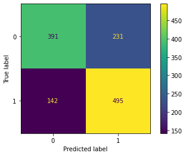

```python
plot_confusion_matrix(clf.best_estimator_, X, y)
```

```
[Text(0.5, 0.8333333333333334, 'family_history_Yes <= 0.5\nentropy = 1.0\nsamples = 843\nvalue = [422, 421]\nclass = y[0]'),
```

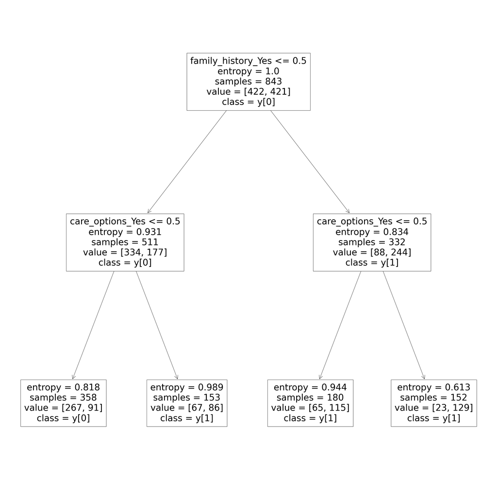

```python
from sklearn import tree

plt.figure(figsize=(40, 40))
tree.plot_tree(clf.best_estimator_, feature_names=feature_names, class_names=True)
```

## CatBoost Classifier

Creating the classifier and tuning parameters. Tested values:

[output not shown]

```python
from catboost import CatBoostClassifier

model = CatBoostClassifier(logging_level='Silent', cat_features=[name for name in X_train.columns if X_train[name].dtype == "O"])

parameters = {
                  'iterations': [5, 10,100,200],
                  'depth'  :  [1,2,3,4,5,6,7,8,9,10],
                  'learning_rate' : [0.001, 0.01, 0.1],
                  'l2_leaf_reg': [1,3,10,100],
             }


clf = RandomizedSearchCV(model, parameters, refit=True,  cv=10, n_jobs=4, verbose=1)
clf.fit(X_train, y_train)


acc, std = clf.cv_results_['mean_test_score'][clf.best_index_]*100, clf.cv_results_['std_test_score'][clf.best_index_]*100

print(f"ACC={acc}%")
print(f"STD={std}%")

res += [dict(name="CatBoost", acc=acc, std=std) for acc, std in zip(clf.cv_results_['mean_test_score'], clf.cv_results_['std_test_score'])]
```

```
Fitting 10 folds for each of 10 candidates, totalling 100 fits
ACC=70.24369747899158%
STD=6.89438826194107%
```

```
<sklearn.metrics._plot.confusion_matrix.ConfusionMatrixDisplay at 0x1d273f567f0>
```

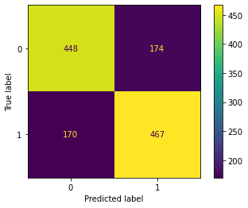

```python
plot_confusion_matrix(clf.best_estimator_, X, y)
```

## VotingClassifier (QDA + DecisionTreeClassifier)

```python
from sklearn.ensemble import VotingClassifier
from sklearn.discriminant_analysis import QuadraticDiscriminantAnalysis
import numpy as np

model = VotingClassifier(  [("quadratic",QuadraticDiscriminantAnalysis()),  ("tree", DecisionTreeClassifier())],n_jobs=4)

grid = dict(
    quadratic__reg_param=np.arange(0, 0.01, 1),
    tree__min_samples_leaf=range(1, 100),
    tree__max_features=['sqrt', 'log2', None],
    tree__criterion = ["gini","entropy"],
    voting=['soft', 'hard'],
)

clf = RandomizedSearchCV(model, grid, refit=True, cv=10, n_jobs=4,  verbose=1)
clf.fit(X, y)

acc, std = clf.cv_results_['mean_test_score'][clf.best_index_]*100, clf.cv_results_['std_test_score'][clf.best_index_]*100

print(f"ACC={acc}%")
print(f"STD={std}%")

res += [dict(name="Voting (QDA + DecTree)", acc=acc, std=std) for acc, std in zip(clf.cv_results_['mean_test_score'], clf.cv_results_['std_test_score'])]
```

```
Fitting 10 folds for each of 10 candidates, totalling 100 fits
ACC=60.927619047619054%
STD=6.144122391333654%
```

```
<sklearn.metrics._plot.confusion_matrix.ConfusionMatrixDisplay at 0x1d2743d82e0>
```

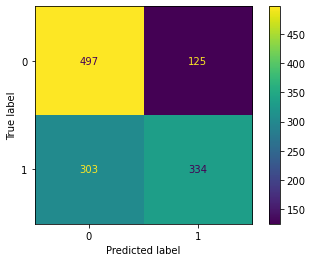

```python
plot_confusion_matrix(clf.best_estimator_, X, y)
```

## Analysis of the results obtained. Conclusions.

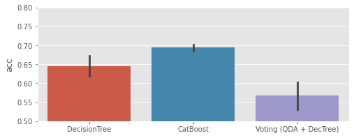

```python
import seaborn as sns
plt.style.use('ggplot')
plt.figure(figsize=(8, 3))
sns.barplot(x='name', y='acc', ci='sd', data=pd.DataFrame(res))
plt.xticks(rotation=0)
plt.xlabel('')
plt.ylim(0.5, 0.8)
plt.show()
```

Among the tested classifiers, CatBoost showed the best accuracy and the smallest standard deviation. The decision tree turned out to be slightly worse, and the VotingClassifier yielded the worst results with a relatively large standard deviation. While the high prediction quality of CatBoost is not surprising, the poor performance of the VotingClassifier and the relatively large standard deviation of the results are intriguing. I suspect that to improve the prediction quality in this case, it would be necessary to change the types of component classifiers involved in voting for the prediction result.

Since the analysis covers topics related to health and medicine, I also compared the classifiers used in terms of false negatives, which, when occurring in a real medical system, can have very negative consequences because they mean that a problem was not detected in the classification process, even though it actually existed:

- DecisionTree: 142 FN
- CatBoost: 170 FN
- VotingClassifier: 303 FN

The above comparison shows that the decision tree, despite its average accuracy, made the fewest false negative errors. Therefore, in future work on the project, I would not discard this classifier. CatBoost performed slightly worse, and the VotingClassifier made 303 FN errors, which, combined with its very poor overall accuracy, provides grounds for considering it ineffective.

In further work on the project, I would focus on more appropriate completion of missing data (e.g., using machine learning tools), the application of other types of classifiers in the VotingClassifier or another ensemble classifier, and I would also try to obtain higher-quality training data. The analyzed dataset comes from 2014, and there are subsequent releases, suggesting that newer versions are better prepared qualitatively and substantively.